# GestÃ£o de Branding no Agro

Aula 13 — Plataforma de Marca  
Propósito, Valores, Personalidade e Tom de Voz

Luiz Diego Vidal Santos

## VisÃ£o Geral

### TÃ³picos Principais

- 1 O que Ã© a plataforma de marca
- 2 Propósito, visão e valores
- 3 Personalidade e personificação
- 4 Tom de voz e narrativa
- 5 Multissensorialidade e atributos

**Objetivo da Aula**

Construir a plataforma completa de marca — o documento-guia que consolida identidade, personalidade e expressão para orientar todas as decisões da marca.

## PLATAFORMA DE MARCA

A plataforma Ã© o **DNA documentado** da marca. Organiza tudo em camadas:

[output not shown]

Do núcleo Ã superfície — cada camada deriva da anterior.

## DO DNA À CONSTRUÇÃO DE VALOR

[figure not shown]

A plataforma documenta quem a marca é, do DNA Ã construção de valor

## PROPÓSITO — “POR QUE EXISTIMOS?”

O propósito é a razão de existir **além do lucro**.

**FÃ³rmula:** Existimos para **[verbo]** + **[para quem]** + **[de que forma]**.

| Marca (fictícia) | Propósito |
| --- | --- |
| Cooperativa Serra Verde | “Conectar produtores de montanha ao mercado que valoriza terroir” |
| Fazenda Raízes | “Provar que pecuária regenerativa gera alimento e restaura ecossistemas” |
| AgroTech Sementes | “Democratizar genética de alta performance para agricultores familiares” |

**Tip**

**Teste:** Se trocar o nome da marca e o propósito ainda servir, ele é genérico demais.

## CULTURA, ESTRATÃ‰GIA E PLATAFORMA

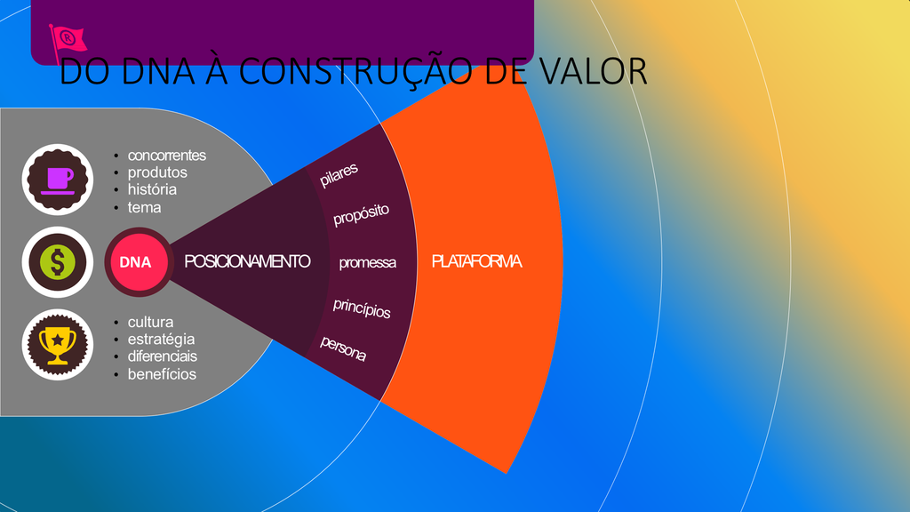

Cultura, estratégia, diferenciais, benefícios e concorrência integrados

## VISÃƒO E VALORES

**Visão** — O futuro desejado (aspiracional mas plausível)

> “Que todo produtor de cafÃ© especial do Cerrado seja reconhecido e remunerado pela singularidade do seu terroir.”

**Valores** — Princípios inegociáveis (3-5):

| Valor fraco âŒ | Valor forte âœ… |
| --- | --- |
| “Qualidade” | “Rastreabilidade radical” |
| “Honestidade” | “Transparência proativa” |
| “Inovação” | “Experimentação de campo” |
| “Sustentabilidade” | “Regeneração mensurável” |

> **Teste de valor:** Se o valor nunca gera dilema ou sacrifício, é genérico.

## CULTURA, VALORES E PROPÃ“SITO

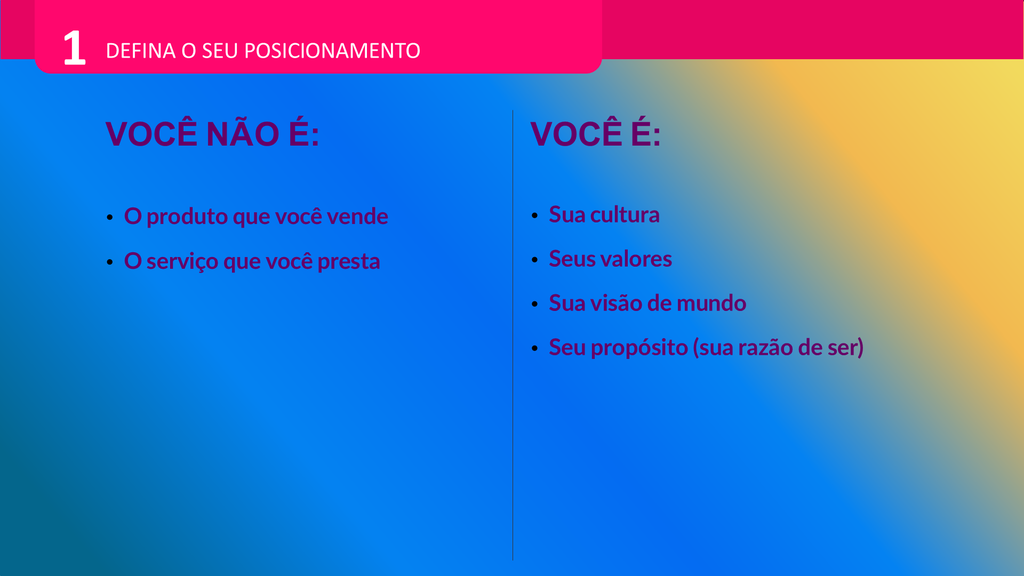

Cultura, valores, visão de mundo e propósito formam a base estratégica

## PERSONALIDADE â€” “SE A MARCA FOSSE UMA PESSOA?”

Exercício de personificação:

| Pergunta | Responda para sua marca |
| --- | --- |
| Que idade teria? |  |
| Como se vestiria? |  |
| Que tipo de música ouviria? |  |
| Como receberia alguém em casa? |  |
| Que assunto dominaria em uma conversa? |  |
| O que a irritaria profundamente? |  |
| Qual seria seu lema de vida? |  |

As respostas revelam a personalidade e guiam o tom de toda a comunicação.

## TOM DE VOZ

O tom de voz traduz a personalidade em linguagem:

| Dimensão | â† Polo A | Polo B â†’ |
| --- | --- | --- |
| **Formalidade** | Formal, institucional | Informal, próxima |
| **Humor** | Sério, sóbrio | Leve, bem-humorado |
| **Entusiasmo** | Contido, discreto | Vibrante, empolgado |
| **Linguagem** | Técnica, precisa | Simples, acessível |
| **Posição** | Autoridade que ensina | Parceiro que caminha junto |

Para cada dimensão, marque onde sua marca se posiciona. Isso cria um **guia prático** para qualquer pessoa que escreva em nome da marca.

## NARRATIVA — “QUAL É A HISTÓRIA?”

Toda marca forte conta uma histÃ³ria. Estrutura:

1. **Origem** â€” De onde viemos
2. **Desafio** â€” Qual problema enxergamos
3. **Escolha** â€” O que decidimos fazer diferente
4. **Método** — O “jeito” da marca
5. **Impacto** â€” O que mudou por causa do nosso trabalho

> “A Serra Verde nasceu quando 12 famílias perceberam que seus cafés especiais eram vendidos como genéricos. Decidiram se unir, processar localmente e vender com identidade. Hoje, cada lote carrega o nome da família que o cultivou.”

## QUEM NÃƒO SOMOS

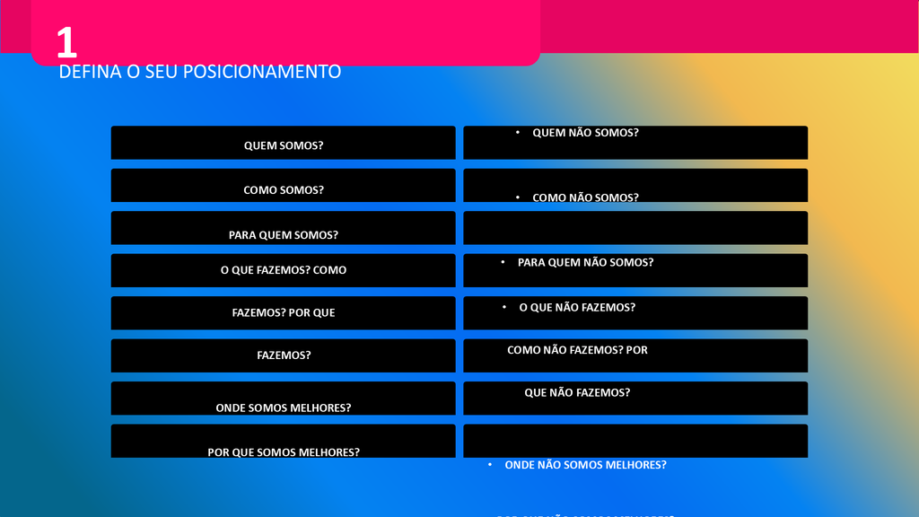

Definir quem não somos é tão importante quanto definir o que somos

## MULTISSENSORIALIDADE

Marcas fortes ativam múltiplos sentidos. No agro, é vantagem natural:

| Sentido | Pergunta | Exemplo |
| --- | --- | --- |
| **Visão** | Cores e paisagens da marca? | Verde escuro do cafezal sombreado |
| **Olfato** | Aromas associados? | Café recém-torrado |
| **Tato** | Texturas que comunicam a marca? | Rugosidade do saco de juta |
| **Paladar** | Sabor que define a experiência? | Acidez frutada |
| **Audição** | Sons que representam? | Canto dos pássaros na agrofloresta |

## ATRIBUTOS DA MARCA

Posicione sua marca em cada espectro:

[output not shown]

O perfil resultante é a “impressão digital” da personalidade.

## CANVAS COMPLETO

### Canvas da Plataforma de Marca Agro

| Componente | Conteúdo |
| --- | --- |
| **Propósito** | *Por que existimos?* |
| **Visão** | *Que futuro queremos?* |
| **Valores** | *Em que acreditamos? (3-5)* |
| **Público ideal** | *Para quem existimos?* |
| **Posicionamento** | *Para / é / que / porque* |
| **Personalidade** | *3-5 traços humanos* |
| **Tom de voz** | *Como fala? Como NÃO fala?* |
| **Narrativa** | *Origem â†’ Desafio â†’ Escolha â†’ Método â†’ Impacto* |

## EXERCÃCIO EM SALA

### Atividade: Construção da Plataforma

Preencha o Canvas completo para a marca trabalhada ao longo da disciplina:

1. Defina **propósito, visão e 3-5 valores**
2. Faça o exercício de **personificação**
3. Defina o **tom de voz** em cada dimensÃ£o
4. Escreva a **narrativa** em 5 frases (Origem â†’ Impacto)
5. Preencha o **mapa sensorial**
6. Marque os **atributos** no espectro

**Este exercício é parte do trabalho final da disciplina.**

Tempo: 30 minutos.

## REFERÃŠNCIAS

- AAKER, D. A. *Aaker on Branding*. Morgan James, 2014.
- WHEELER, A. *Designing Brand Identity*. 5Âª ed. Wiley, 2018.
- MARK, M.; PEARSON, C. S. *O HerÃ³i e o Fora da Lei*. Cultrix, 2001.
- HOLT, D. *How Brands Become Icons*. Harvard Business Review Press, 2004.